# Astronaut database

Federico Di Franco

Henry Michel Iannella Jones

Francesco Pierri

## 1. Data Loading

We load the data from the local data directory. If the local file is not found, we download it directly from the TidyTuesday GitHub repository and save a local copy for future runs.

```r
local_path <- "data/astronauts.csv"
url <- "https://raw.githubusercontent.com/rfordatascience/tidytuesday/main/data/2020/2020-07-14/astronauts.csv"

if (file.exists(local_path)) {
  message("Loading dataset from local path: ", local_path)
  astronauts_raw <- read_csv(local_path)
} else {
  message("Local dataset not found. Downloading from TidyTuesday GitHub repository...")
  astronauts_raw <- read_csv(url)
  # Save locally for future use
  write_csv(astronauts_raw, local_path)
}

# Clean column names for easier typing and consistency
astronauts <- astronauts_raw %>%
  clean_names()

# Check initial number of rows
nrow(astronauts)
```

```
## [1] 1277
```

```r
# Display the first few rows to understand the data
head(astronauts)
```

```
## # A tibble: 6 × 24
##      id number nationwide_number name          original_name sex   year_of_birth
##   <dbl>  <dbl>             <dbl> <chr>         <chr>         <chr>         <dbl>
## 1     1      1                 1 Gagarin, Yuri ГАГАРИН Юрий… male           1934
## 2     2      2                 2 Titov, Gherm… ТИТОВ Герман… male           1935
## 3     3      3                 1 Glenn, John … Glenn, John … male           1921
## 4     4      3                 1 Glenn, John … Glenn, John … male           1921
## 5     5      4                 2 Carpenter, M… Carpenter, M… male           1925
## 6     6      5                 2 Nikolayev, A… НИКОЛАЕВ Анд… male           1929
## # ℹ 17 more variables: nationality <chr>, military_civilian <chr>,
## #   selection <chr>, year_of_selection <dbl>, mission_number <dbl>,
## #   total_number_of_missions <dbl>, occupation <chr>, year_of_mission <dbl>,
## #   mission_title <chr>, ascend_shuttle <chr>, in_orbit <chr>,
## #   descend_shuttle <chr>, hours_mission <dbl>, total_hrs_sum <dbl>,
## #   field21 <dbl>, eva_hrs_mission <dbl>, total_eva_hrs <dbl>
```

## 2. Examining Data Structure

Next, we examine the dataset to understand its structure, dimensions, and the types of variables it contains. We use `str()` as recommended to avoid structure-related mistakes.

```r
# Check the structure and data types
str(astronauts)
```

```
## spc_tbl_ [1,277 × 24] (S3: spec_tbl_df/tbl_df/tbl/data.frame)
##  $ id                      : num [1:1277] 1 2 3 4 5 6 7 8 9 10 ...
##  $ number                  : num [1:1277] 1 2 3 3 4 5 5 6 6 7 ...
##  $ nationwide_number       : num [1:1277] 1 2 1 1 2 2 2 4 4 3 ...
##  $ name                    : chr [1:1277] "Gagarin, Yuri" "Titov, Gherman" "Glenn, John H., Jr." "Glenn, John H., Jr." ...
##  $ original_name           : chr [1:1277] "ГАГАРИН Юрий Алексеевич" "ТИТОВ Герман Степанович" "Glenn, John H., Jr." "Glenn, John H., Jr." ...
##  $ sex                     : chr [1:1277] "male" "male" "male" "male" ...
##  $ year_of_birth           : num [1:1277] 1934 1935 1921 1921 1925 ...
##  $ nationality             : chr [1:1277] "U.S.S.R/Russia" "U.S.S.R/Russia" "U.S." "U.S." ...
##  $ military_civilian       : chr [1:1277] "military" "military" "military" "military" ...
##  $ selection               : chr [1:1277] "TsPK-1" "TsPK-1" "NASA Astronaut Group 1" "NASA Astronaut Group 2" ...
##  $ year_of_selection       : num [1:1277] 1960 1960 1959 1959 1959 ...
##  $ mission_number          : num [1:1277] 1 1 1 2 1 1 2 1 2 1 ...
##  $ total_number_of_missions: num [1:1277] 1 1 2 2 1 2 2 2 2 3 ...
##  $ occupation              : chr [1:1277] "pilot" "pilot" "pilot" "PSP" ...
##  $ year_of_mission         : num [1:1277] 1961 1961 1962 1998 1962 ...
##  $ mission_title           : chr [1:1277] "Vostok 1" "Vostok 2" "MA-6" "STS-95" ...
##  $ ascend_shuttle          : chr [1:1277] "Vostok 1" "Vostok 2" "MA-6" "STS-95" ...
##  $ in_orbit                : chr [1:1277] "Vostok 2" "Vostok 2" "MA-6" "STS-95" ...
##  $ descend_shuttle         : chr [1:1277] "Vostok 3" "Vostok 2" "MA-6" "STS-95" ...
##  $ hours_mission           : num [1:1277] 1.77 25 5 213 5 ...
##  $ total_hrs_sum           : num [1:1277] 1.77 25.3 218 218 5 ...
##  $ field21                 : num [1:1277] 0 0 0 0 0 0 0 0 0 0 ...
##  $ eva_hrs_mission         : num [1:1277] 0 0 0 0 0 0 0 0 0 0 ...
##  $ total_eva_hrs           : num [1:1277] 0 0 0 0 0 0 0 0 0 0 ...
##  - attr(*, "spec")=
##   .. cols(
##   ..   id = col_double(),
##   ..   number = col_double(),
##   ..   nationwide_number = col_double(),
##   ..   name = col_character(),
##   ..   original_name = col_character(),
##   ..   sex = col_character(),
##   ..   year_of_birth = col_double(),
##   ..   nationality = col_character(),
##   ..   military_civilian = col_character(),
##   ..   selection = col_character(),
##   ..   year_of_selection = col_double(),
##   ..   mission_number = col_double(),
##   ..   total_number_of_missions = col_double(),
##   ..   occupation = col_character(),
##   ..   year_of_mission = col_double(),
##   ..   mission_title = col_character(),
##   ..   ascend_shuttle = col_character(),
##   ..   in_orbit = col_character(),
##   ..   descend_shuttle = col_character(),
##   ..   hours_mission = col_double(),
##   ..   total_hrs_sum = col_double(),
##   ..   field21 = col_double(),
##   ..   eva_hrs_mission = col_double(),
##   ..   total_eva_hrs = col_double()
##   .. )
##  - attr(*, "problems")=<externalptr>
```

```r
# Show basic summary statistics
summary(astronauts)
```

```
##        id           number      nationwide_number     name
##  Min.   :   1   Min.   :  1.0   Min.   :  1.0     Length:1277
##  1st Qu.: 320   1st Qu.:153.0   1st Qu.: 47.0     Class :character
##  Median : 639   Median :278.0   Median :110.0     Mode  :character
##  Mean   : 639   Mean   :274.2   Mean   :128.8
##  3rd Qu.: 958   3rd Qu.:390.0   3rd Qu.:204.0
##  Max.   :1277   Max.   :565.0   Max.   :433.0
##  original_name          sex            year_of_birth  nationality
##  Length:1277        Length:1277        Min.   :1921   Length:1277
##  Class :character   Class :character   1st Qu.:1944   Class :character
##  Mode  :character   Mode  :character   Median :1952   Mode  :character
##                                        Mean   :1952
##                                        3rd Qu.:1959
##                                        Max.   :1983
##  military_civilian   selection         year_of_selection mission_number
##  Length:1277        Length:1277        Min.   :1959      Min.   :1.000
##  Class :character   Class :character   1st Qu.:1978      1st Qu.:1.000
##  Mode  :character   Mode  :character   Median :1987      Median :2.000
##                                        Mean   :1986      Mean   :1.992
##                                        3rd Qu.:1995      3rd Qu.:3.000
##                                        Max.   :2018      Max.   :7.000
##  total_number_of_missions  occupation        year_of_mission mission_title
##  Min.   :1.000            Length:1277        Min.   :1961    Length:1277
##  1st Qu.:2.000            Class :character   1st Qu.:1986    Class :character
##  Median :3.000            Mode  :character   Median :1995    Mode  :character
##  Mean   :2.983                               Mean   :1995
##  3rd Qu.:4.000                               3rd Qu.:2003
##  Max.   :7.000                               Max.   :2019
##  ascend_shuttle       in_orbit         descend_shuttle    hours_mission
##  Length:1277        Length:1277        Length:1277        Min.   :    0
##  Class :character   Class :character   Class :character   1st Qu.:  190
##  Mode  :character   Mode  :character   Mode  :character   Median :  261
##                                                           Mean   : 1051
##                                                           3rd Qu.:  382
##                                                           Max.   :10505
##  total_hrs_sum         field21       eva_hrs_mission  total_eva_hrs
##  Min.   :    0.61   Min.   :0.0000   Min.   : 0.000   Min.   : 0.00
##  1st Qu.:  482.00   1st Qu.:0.0000   1st Qu.: 0.000   1st Qu.: 0.00
##  Median :  932.00   Median :0.0000   Median : 0.000   Median : 0.00
##  Mean   : 2968.34   Mean   :0.6288   Mean   : 3.661   Mean   :10.76
##  3rd Qu.: 4264.00   3rd Qu.:1.0000   3rd Qu.: 4.720   3rd Qu.:19.52
##  Max.   :21083.52   Max.   :7.0000   Max.   :89.130   Max.   :78.80
```

Now, we will check for potential typos in categorical variables. This is important because typos can lead to incorrect groupings and analyses later on. We will look at the unique values in key categorical columns to identify any inconsistencies.

```r
# Explore specific categorical columns for typos (e.g., 'pilot' vs 'Pilot')
# We sort alphabetically to make case-sensitivity issues stand out
typo_cols <- c("sex", "nationality", "military_civilian", "occupation")
for (col in typo_cols) {
  cat("\n--- Column:", col, "---\n")
  astronauts %>%
    count(.data[[col]]) %>%
    arrange(.data[[col]]) %>%
    print(n = Inf) # Print all values to ensure no typo is missed
}
```

```
##
## --- Column: sex ---
## # A tibble: 2 × 2
##   sex        n
##   <chr>  <int>
## 1 female   143
## 2 male    1134
##
## --- Column: nationality ---
## # A tibble: 40 × 2
##    nationality                  n
##    <chr>                    <int>
##  1 Afghanistan                  1
##  2 Australia                    4
##  3 Austria                      1
```

[output cut: 61 more lines]

As we can see from the output above, there are some data entry inconsistencies. For example, in the `occupation` column we have both `"Pilot"` and `"pilot"`, or `"Space tourist"` and `"space tourist"`. We will address these case-sensitivity issues automatically in the cleaning phase.

## 3. Handling Missing Values and Inconsistencies

Before doing calculations, it is crucial to check for missing values and fix categorical inconsistencies.

```r
# Count missing values per column
colSums(is.na(astronauts))
```

```
##                       id                   number        nationwide_number
##                        0                        0                        0
##                     name            original_name                      sex
##                        0                        5                        0
##            year_of_birth              nationality        military_civilian
##                        0                        0                        0
##                selection        year_of_selection           mission_number
##                        1                        0                        0
## total_number_of_missions               occupation          year_of_mission
##                        0                        0                        0
##            mission_title           ascend_shuttle                 in_orbit
##                        1                        1                        0
##          descend_shuttle            hours_mission            total_hrs_sum
##                        1                        0                        0
##                  field21          eva_hrs_mission            total_eva_hrs
##                        0                        0                        0
```

```r
# Isolate rows that contain at least one missing value (NA) in any column
rows_with_na <- astronauts %>%
  filter(if_any(everything(), is.na))
cat("\nTotal rows with at least one missing value:", nrow(rows_with_na), "\n")
```

```
##
## Total rows with at least one missing value: 8
```

We will inspect the rows with missing values to understand the nature of the missing data. This helps us decide how to handle them appropriately (e.g., whether to impute, drop, or categorize as “Unknown”).

```r
# Display the first few of these rows to visually inspect the missing data
head(rows_with_na)
```

```
## # A tibble: 6 × 24
##      id number nationwide_number name          original_name sex   year_of_birth
##   <dbl>  <dbl>             <dbl> <chr>         <chr>         <chr>         <dbl>
## 1   186     87                 1 Vladimir Rem… <NA>          male           1948
## 2   198     94                 1 Bertalan Far… Farkas Berta… male           1949
## 3   369    173                 1 Al-saud, Sul… <NA>          male           1956
## 4   416    195                 1 Neri Vela, R… <NA>          male           1952
## 5   438    205                 1 Faris, M. Ac… <NA>          male           1951
## 6   450    211                 1 Mohmand, Abd… <NA>          male           1959
## # ℹ 17 more variables: nationality <chr>, military_civilian <chr>,
## #   selection <chr>, year_of_selection <dbl>, mission_number <dbl>,
## #   total_number_of_missions <dbl>, occupation <chr>, year_of_mission <dbl>,
## #   mission_title <chr>, ascend_shuttle <chr>, in_orbit <chr>,
## #   descend_shuttle <chr>, hours_mission <dbl>, total_hrs_sum <dbl>,
## #   field21 <dbl>, eva_hrs_mission <dbl>, total_eva_hrs <dbl>
```

We will remove rows that are completely empty (if any). We make sure to check the number of rows before and after filtering to ensure we don’t drop data unintentionally, even though we know there will be no NA numbers from the previous check, this makes our code robust for future additions as well.

```r
# Check rows before filtering
n_rows_before <- nrow(astronauts)
astronauts_clean <- astronauts %>%
  # Remove rows where the key identifier 'number' is NA
  filter(!is.na(number))

# Check rows after filtering to ensure we didn't drop too much
n_rows_after <- nrow(astronauts_clean)
cat("Rows removed:", n_rows_before - n_rows_after, "\n")
```

```
## Rows removed: 0
```

Next, we will normalize all character columns to lowercase to automatically fix case typos (e.g., ‘Pilot’ -> ‘pilot’). This is much safer and scalable than fixing typos manually one by one. We will also handle missing observations appropriately by replacing NA values in character columns with “Unknown”. This way, we keep the numerical data of those astronauts intact while still acknowledging the missing information.

```r
# Normalize all character columns to lowercase to automatically fix case typos (e.g., 'Pilot' -> 'pilot')
# This is much safer and scalable than fixing typos manually one by one.
astronauts_clean <- astronauts_clean %>%
  mutate(
    across(where(is.character), str_to_lower)
  )

# Handle missing observations appropriately
# Documenting our choice: We use "Unknown" for missing text data instead of dropping rows,
# to keep numerical data of those astronauts intact.
astronauts_clean <- astronauts_clean %>%
  mutate(
    across(where(is.character), ~replace_na(.x, "Unknown"))
  )

# Verify that missing values have been handled
colSums(is.na(astronauts_clean))
```

```
##                       id                   number        nationwide_number
##                        0                        0                        0
##                     name            original_name                      sex
##                        0                        0                        0
##            year_of_birth              nationality        military_civilian
##                        0                        0                        0
##                selection        year_of_selection           mission_number
##                        0                        0                        0
## total_number_of_missions               occupation          year_of_mission
##                        0                        0                        0
##            mission_title           ascend_shuttle                 in_orbit
##                        0                        0                        0
##          descend_shuttle            hours_mission            total_hrs_sum
##                        0                        0                        0
##                  field21          eva_hrs_mission            total_eva_hrs
##                        0                        0                        0
```

In the end, we will verify that all typos have been fixed and that there are no unexpected missing values left in the cleaned dataset.

```r
# Verify that all typos have been fixed by checking unique values again
for (col in typo_cols) {
  cat("\n--- Column:", col, "---\n")
  astronauts_clean %>%
    count(.data[[col]]) %>%
    arrange(.data[[col]]) %>%
    print(n = Inf) # Print all values to ensure no typo is missed
}
```

```
##
## --- Column: sex ---
## # A tibble: 2 × 2
##   sex        n
##   <chr>  <int>
## 1 female   143
## 2 male    1134
##
## --- Column: nationality ---
## # A tibble: 40 × 2
##    nationality                  n
##    <chr>                    <int>
##  1 afghanistan                  1
##  2 australia                    4
##  3 austria                      1
```

[output cut: 58 more lines]

Now we can see that while the case-sensitivity issues have been resolved, there is still an inconsistency in the `occupation` column: some values contain the redundant prefix `"other (...)"` (e.g., `"other (journalist)"` and `"other (space tourist)"`).

We want to extract just the specific role from inside the parentheses. We can do this cleanly using regular expressions with `str_replace()`:

```r
# Use regular expressions to extract the text inside 'other (...)'
astronauts_clean <- astronauts_clean %>%
  mutate(
    occupation = str_replace(occupation, "other \\((.*?)\\)", "\\1")
  )

# Verify the final cleaned occupation column
cat("\n--- Final 'occupation' column ---\n")
```

```
##
## --- Final 'occupation' column ---
```

```r
astronauts_clean %>%
  count(occupation) %>%
  arrange(occupation) %>%
  print(n = Inf)
```

```
## # A tibble: 8 × 2
##   occupation                  n
##   <chr>                   <int>
## 1 commander                 315
## 2 flight engineer           196
## 3 journalist                  1
## 4 msp                       498
## 5 pilot                     197
## 6 psp                        59
## 7 space tourist              10
## 8 spaceflight participant     1
```

## 4. Data Transformation

Finally, we transform the data types to make the dataset suitable for analysis, such as converting characters to factors where appropriate. This will help with any categorical analyses we want to perform later on.

```r
# Convert relevant character columns to factors
astronauts_clean <- astronauts_clean %>%
  mutate(
    sex = as.factor(sex),
    military_civilian = as.factor(military_civilian),
    nationality = as.factor(nationality),
    occupation = as.factor(occupation)
  )

# Save the cleaned dataset to the data directory
write_csv(astronauts_clean, "data/astronauts_clean.csv")

# Verify the final structure
str(astronauts_clean)
```

```
## tibble [1,277 × 24] (S3: tbl_df/tbl/data.frame)
##  $ id                      : num [1:1277] 1 2 3 4 5 6 7 8 9 10 ...
##  $ number                  : num [1:1277] 1 2 3 3 4 5 5 6 6 7 ...
##  $ nationwide_number       : num [1:1277] 1 2 1 1 2 2 2 4 4 3 ...
##  $ name                    : chr [1:1277] "gagarin, yuri" "titov, gherman" "glenn, john h., jr." "glenn, john h., jr." ...
##  $ original_name           : chr [1:1277] "гагарин юрий алексеевич" "титов герман степанович" "glenn, john h., jr." "glenn, john h., jr." ...
##  $ sex                     : Factor w/ 2 levels "female","male": 2 2 2 2 2 2 2 2 2 2 ...
##  $ year_of_birth           : num [1:1277] 1934 1935 1921 1921 1925 ...
##  $ nationality             : Factor w/ 40 levels "afghanistan",..: 37 37 36 36 36 37 37 37 37 36 ...
##  $ military_civilian       : Factor w/ 2 levels "civilian","military": 2 2 2 2 2 2 2 2 2 2 ...
##  $ selection               : chr [1:1277] "tspk-1" "tspk-1" "nasa astronaut group 1" "nasa astronaut group 2" ...
##  $ year_of_selection       : num [1:1277] 1960 1960 1959 1959 1959 ...
##  $ mission_number          : num [1:1277] 1 1 1 2 1 1 2 1 2 1 ...
##  $ total_number_of_missions: num [1:1277] 1 1 2 2 1 2 2 2 2 3 ...
##  $ occupation              : Factor w/ 8 levels "commander","flight engineer",..: 5 5 5 6 5 5 5 5 1 5 ...
##  $ year_of_mission         : num [1:1277] 1961 1961 1962 1998 1962 ...
##  $ mission_title           : chr [1:1277] "vostok 1" "vostok 2" "ma-6" "sts-95" ...
##  $ ascend_shuttle          : chr [1:1277] "vostok 1" "vostok 2" "ma-6" "sts-95" ...
##  $ in_orbit                : chr [1:1277] "vostok 2" "vostok 2" "ma-6" "sts-95" ...
##  $ descend_shuttle         : chr [1:1277] "vostok 3" "vostok 2" "ma-6" "sts-95" ...
##  $ hours_mission           : num [1:1277] 1.77 25 5 213 5 ...
##  $ total_hrs_sum           : num [1:1277] 1.77 25.3 218 218 5 ...
##  $ field21                 : num [1:1277] 0 0 0 0 0 0 0 0 0 0 ...
##  $ eva_hrs_mission         : num [1:1277] 0 0 0 0 0 0 0 0 0 0 ...
##  $ total_eva_hrs           : num [1:1277] 0 0 0 0 0 0 0 0 0 0 ...
```

The dataset `astronauts_clean` is now prepared and can be used for the next step: Exploratory Data Analysis.

# Exploratory Data Analysis

## 1. Description of Variables and Descriptive Statistics

The `astronauts_clean` dataset contains details about astronauts, their missions, and the time spent in space and on spacewalks (EVAs). We first calculate basic descriptive statistics for some key numerical variables.

```r
# Summary of numerical features
astronauts_clean %>%
  summarise(
    n_obs = n(),
    mean_hours = round(mean(total_hrs_sum, na.rm = TRUE), 1),
    median_hours = round(median(total_hrs_sum, na.rm = TRUE), 1),
    sd_hours = round(sd(total_hrs_sum, na.rm = TRUE), 1),
    max_hours = round(max(total_hrs_sum, na.rm = TRUE), 1),
    mean_eva = round(mean(total_eva_hrs, na.rm = TRUE), 1),
    max_eva = round(max(total_eva_hrs, na.rm = TRUE), 1)
  )
```

```
## # A tibble: 1 × 7
##   n_obs mean_hours median_hours sd_hours max_hours mean_eva max_eva
##   <int>      <dbl>        <dbl>    <dbl>     <dbl>    <dbl>   <dbl>
## 1  1277      2968.          932    4215.    21084.     10.8    78.8
```

```r
# Missing values check specifically before the next transformations
astronauts_clean %>%
  summarise(across(everything(), ~ sum(is.na(.x)), .names = "na_{.col}"))
```

```
## # A tibble: 1 × 24
##   na_id na_number na_nationwide_number na_name na_original_name na_sex
##   <int>     <int>                <int>   <int>            <int>  <int>
## 1     0         0                    0       0                0      0
## # ℹ 18 more variables: na_year_of_birth <int>, na_nationality <int>,
## #   na_military_civilian <int>, na_selection <int>, na_year_of_selection <int>,
## #   na_mission_number <int>, na_total_number_of_missions <int>,
## #   na_occupation <int>, na_year_of_mission <int>, na_mission_title <int>,
## #   na_ascend_shuttle <int>, na_in_orbit <int>, na_descend_shuttle <int>,
## #   na_hours_mission <int>, na_total_hrs_sum <int>, na_field21 <int>,
## #   na_eva_hrs_mission <int>, na_total_eva_hrs <int>
```

## 2. Creation of New Variables

As required, we will create at least 10 new columns (exactly 12) to enrich the dataset with meaningful calculated indicators, aggregated categories, and recoded variables.

```r
astronauts_eda <- astronauts_clean %>%
  mutate(
    # 1. age_at_selection: age when selected
    age_at_selection = year_of_selection - year_of_birth,

    # 2. age_at_mission: age during the mission
    age_at_mission = year_of_mission - year_of_birth,

    # 3. decade_of_mission: grouping missions by decade
    decade_of_mission = as.factor(floor(year_of_mission / 10) * 10),

    # 4. career_duration: time between selection and mission
    career_duration = year_of_mission - year_of_selection,

    # 5. mission_duration_days: mission time in days
    mission_duration_days = hours_mission / 24,

    # 6. total_days_in_space: cumulative mission time in days
    total_days_in_space = total_hrs_sum / 24,

    # 7. is_us_or_ussr: superpower origin vs others
    is_us_or_ussr = as.factor(if_else(str_detect(nationality, "u\\.s\\.|u\\.s\\.s\\.r"), "Superpower", "Other")),
    # Documenting our choice: We use str_detect() instead of exact matching (%in%)
    # to correctly capture dual nationalities or mixed missions that contain a slash,
    # such as "u.k./u.s." and "u.s.s.r/ukraine". This ensures no superpower is missed.

    # 8. has_eva: binary variable indicating if the mission had a spacewalk
    has_eva = as.factor(if_else(eva_hrs_mission > 0, "Yes", "No")),

    # 9. experience_level: distinguishing rookies from veterans
    experience_level = as.factor(case_when(
      mission_number == 1 ~ "Rookie",
      TRUE ~ "Veteran"
    )),

    # 10. eva_percentage: percent of mission time spent on EVA (handling div by 0 just in case)
    eva_percentage = if_else(hours_mission > 0, (eva_hrs_mission / hours_mission) * 100, 0),

    # 11. mission_era: Historical era of spaceflight
    mission_era = factor(case_when(
      year_of_mission < 1975 ~ "Space Race",
      year_of_mission <= 2000 ~ "Shuttle & Mir",
      TRUE ~ "ISS Era"
    ), levels = c("Space Race", "Shuttle & Mir", "ISS Era")),

    # 12. eva_intensity_hrs_per_day: EVA hours normalized by mission duration
    eva_intensity_hrs_per_day = if_else(mission_duration_days > 0, eva_hrs_mission / mission_duration_days, 0)
  )

# Verification of the structure of the new dataset
glimpse(astronauts_eda)
```

```
## Rows: 1,277
## Columns: 36
## $ id                        <dbl> 1, 2, 3, 4, 5, 6, 7, 8, 9, 10, 11, 12, 13, 1…
## $ number                    <dbl> 1, 2, 3, 3, 4, 5, 5, 6, 6, 7, 7, 7, 8, 8, 9,…
## $ nationwide_number         <dbl> 1, 2, 1, 1, 2, 2, 2, 4, 4, 3, 3, 3, 4, 4, 5,…
## $ name                      <chr> "gagarin, yuri", "titov, gherman", "glenn, j…
## $ original_name             <chr> "гагарин юрий алексеевич", "титов герман сте…
## $ sex                       <fct> male, male, male, male, male, male, male, ma…
## $ year_of_birth             <dbl> 1934, 1935, 1921, 1921, 1925, 1929, 1929, 19…
## $ nationality               <fct> u.s.s.r/russia, u.s.s.r/russia, u.s., u.s., …
## $ military_civilian         <fct> military, military, military, military, mili…
## $ selection                 <chr> "tspk-1", "tspk-1", "nasa astronaut group 1"…
## $ year_of_selection         <dbl> 1960, 1960, 1959, 1959, 1959, 1960, 1960, 19…
## $ mission_number            <dbl> 1, 1, 1, 2, 1, 1, 2, 1, 2, 1, 2, 3, 1, 2, 1,…
## $ total_number_of_missions  <dbl> 1, 1, 2, 2, 1, 2, 2, 2, 2, 3, 3, 3, 2, 2, 3,…
```

[output cut: 23 more lines]

## 3. Data Visualizations

Here are 12 meaningful charts to highlight the most important aspects of the data.

```r
# --- Aesthetic Configuration ---
# Toggle this to 'TRUE' for the Dark Mode, or 'FALSE' for the Light Mode
use_dark_mode <- FALSE

if (use_dark_mode) {
  custom_theme <- theme_minimal(base_size = 14) +
    theme(
      plot.background = element_rect(fill = "#1a1a2e", color = NA),
      panel.background = element_rect(fill = "#1a1a2e", color = NA),
      text = element_text(color = "white"),
      axis.text = element_text(color = "gray80"),
      plot.title = element_text(face = "bold", size = 16, color = "white"),
      plot.subtitle = element_text(face = "italic", color = "gray60", size = 12),
      panel.grid.major = element_line(color = "gray30", linewidth = 0.5),
      panel.grid.minor = element_blank(),
      legend.background = element_rect(fill = "#1a1a2e", color = NA),
      legend.text = element_text(color = "white"),
      legend.title = element_text(color = "white", face = "bold"),
      legend.position = "top"
    )
  geom_color <- "#00b4d8"
} else {
  custom_theme <- theme_minimal(base_size = 14) +
    theme(
      plot.background = element_rect(fill = "white", color = NA),
      panel.background = element_rect(fill = "white", color = NA),
      text = element_text(color = "black"),
      axis.text = element_text(color = "black"),
      plot.title = element_text(face = "bold", size = 16, color = "black"),
      plot.subtitle = element_text(face = "italic", color = "gray40", size = 12),
      panel.grid.major = element_line(color = "gray90", linewidth = 0.5),
      panel.grid.minor = element_blank(),
      legend.background = element_rect(fill = "white", color = NA),
      legend.text = element_text(color = "black"),
      legend.title = element_text(color = "black", face = "bold"),
      legend.position = "top"
    )
  geom_color <- "#03045e"
}

# Apply the theme globally so we don't have to repeat it in every chart
theme_set(custom_theme)
```

### Chart 1: Age Distribution During Missions

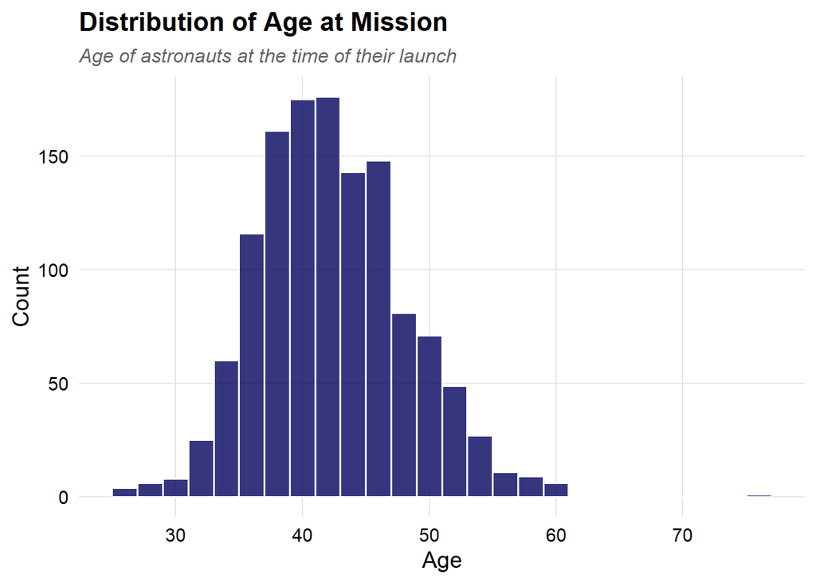

```r
# Why: To see the typical age of astronauts going to space.
# What: A histogram of age at mission.
# How it helps: Gives an idea of the physical requirements and career path timeline.
astronauts_eda %>%
  ggplot(aes(x = age_at_mission)) +
  geom_histogram(binwidth = 2, fill = geom_color, color = "white", alpha = 0.8) +
  labs(
    title = "Distribution of Age at Mission",
    subtitle = "Age of astronauts at the time of their launch",
    x = "Age",
    y = "Count"
  )
```

### Chart 2: Top 10 Nationalities

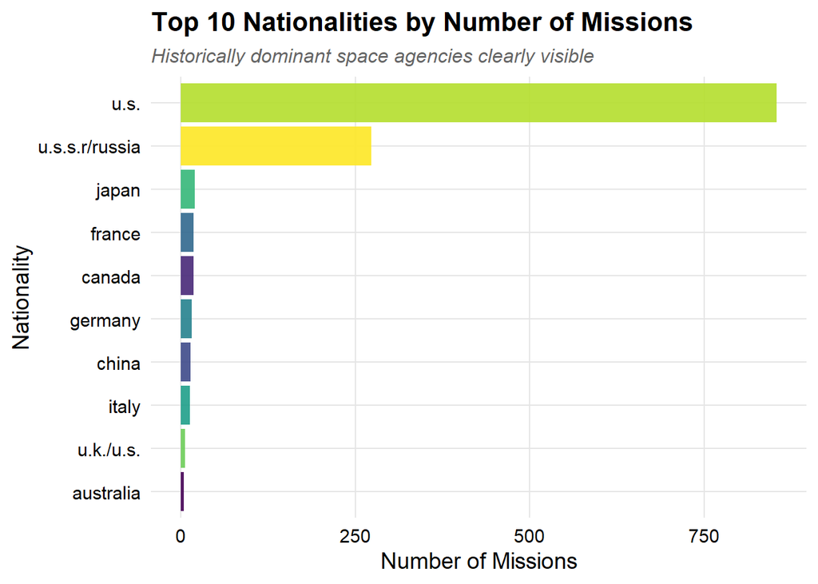

```r
# Why: To understand the geographic distribution of astronauts.
# What: A bar chart counting missions by the top 10 nationalities.
# How it helps: It highlights the historical dominance of specific countries in space exploration.
astronauts_eda %>%
  count(nationality, sort = TRUE) %>%
  slice_head(n = 10) %>%
  ggplot(aes(x = reorder(nationality, n), y = n, fill = nationality)) +
  geom_col(show.legend = FALSE, alpha = 0.9) +
  scale_fill_viridis_d(option = "viridis") +
  coord_flip() +
  labs(
    title = "Top 10 Nationalities by Number of Missions",
    subtitle = "Historically dominant space agencies clearly visible",
    x = "Nationality",
    y = "Number of Missions"
  )
```

### Chart 3: Mission Duration by Sex

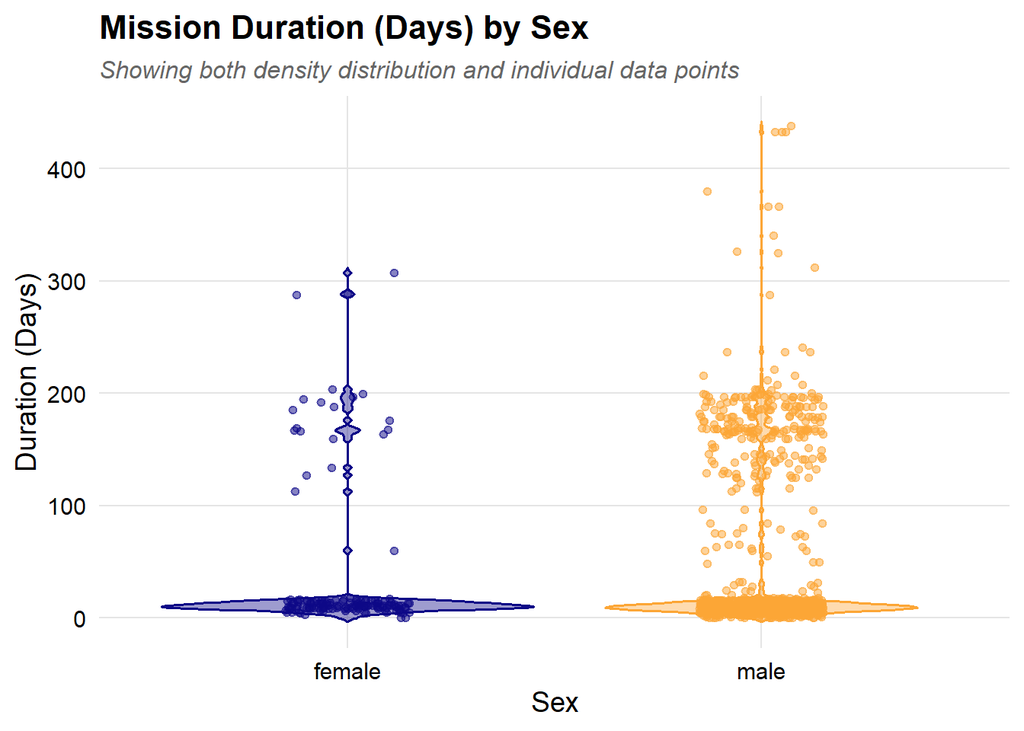

```r
# Why: To check for gender disparities in mission assignments.
# What: A combination of a violin plot and jittered points for mission length.
# How it helps: Unlike a boxplot, this shows both the overall density shape and the exact concentration of individual missions (from short Shuttle flights to long ISS stays).
astronauts_eda %>%
  ggplot(aes(x = sex, y = mission_duration_days, fill = sex, color = sex)) +
  geom_violin(alpha = 0.4, trim = FALSE) +
  geom_jitter(width = 0.15, alpha = 0.5, size = 1.5) +
  scale_fill_viridis_d(option = "plasma", end = 0.8) +
  scale_color_viridis_d(option = "plasma", end = 0.8) +
  labs(
    title = "Mission Duration (Days) by Sex",
    subtitle = "Showing both density distribution and individual data points",
    x = "Sex",
    y = "Duration (Days)"
  ) +
  theme(legend.position = "none")
```

### Chart 4: Total Space Hours over Time

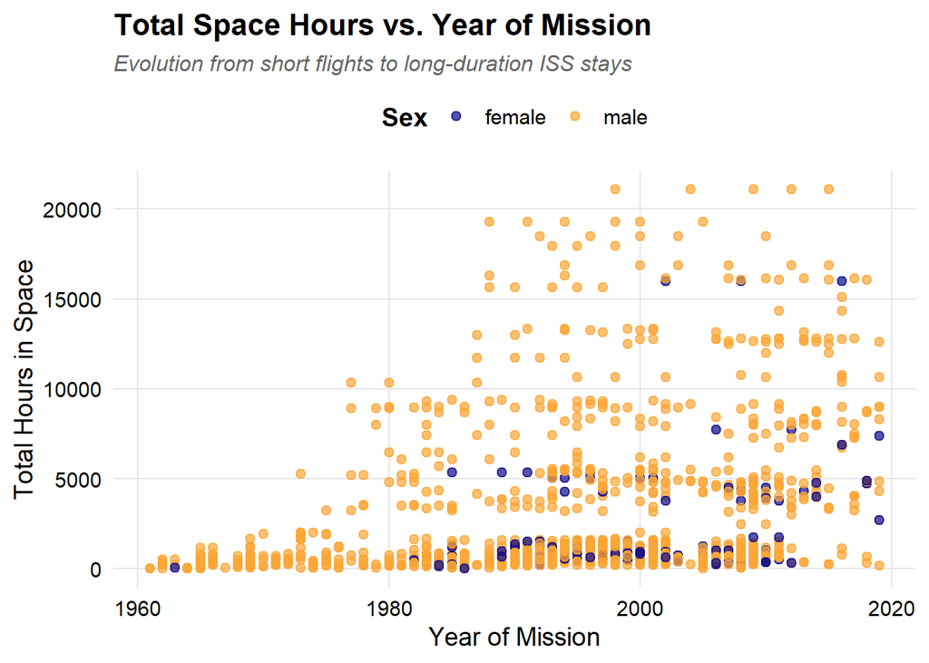

```r
# Why: To see if missions are getting longer historically.
# What: A scatter plot of total hours vs mission year.
# How it helps: Highlights the evolution from short early flights to long-term ISS stays.
astronauts_eda %>%
  ggplot(aes(x = year_of_mission, y = total_hrs_sum, color = sex)) +
  geom_point(alpha = 0.7, size = 2) +
  scale_color_viridis_d(option = "plasma", end = 0.8) +
  labs(
    title = "Total Space Hours vs. Year of Mission",
    subtitle = "Evolution from short flights to long-duration ISS stays",
    x = "Year of Mission",
    y = "Total Hours in Space",
    color = "Sex"
  )
```

### Chart 5: Missions per Year

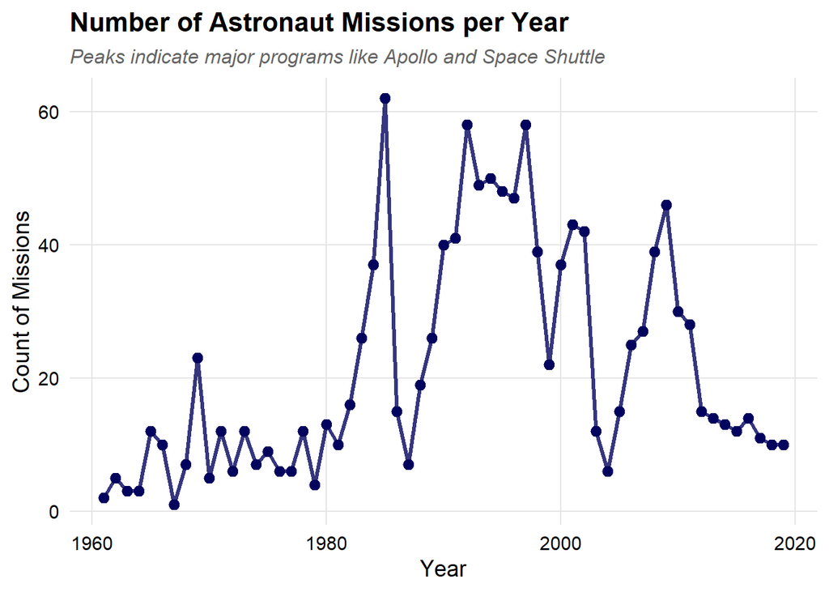

```r
# Why: To observe the pace of space exploration.
# What: A line plot showing the count of missions each year.
# How it helps: Shows peaks during the space race and shuttle eras.
astronauts_eda %>%
  count(year_of_mission) %>%
  ggplot(aes(x = year_of_mission, y = n)) +
  geom_line(color = geom_color, linewidth = 1.2, alpha = 0.8) +
  geom_point(color = geom_color, size = 2.5) +
  labs(
    title = "Number of Astronaut Missions per Year",
    subtitle = "Peaks indicate major programs like Apollo and Space Shuttle",
    x = "Year",
    y = "Count of Missions"
  )
```

### Chart 6: Experience Level of Astronauts

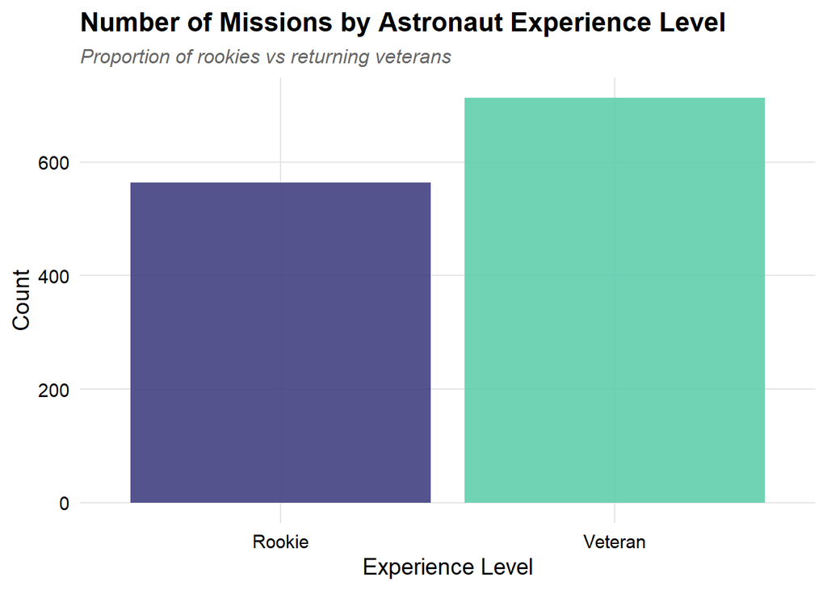

```r
# Why: To check the ratio of rookies vs veterans sent to space.
# What: A bar chart of the experience level.
# How it helps: We can understand if space agencies rely more on fresh faces or experienced crews.
astronauts_eda %>%
  count(experience_level) %>%
  ggplot(aes(x = experience_level, y = n, fill = experience_level)) +
  geom_col(show.legend = FALSE, alpha = 0.9) +
  scale_fill_viridis_d(option = "mako", begin = 0.3, end = 0.8) +
  labs(
    title = "Number of Missions by Astronaut Experience Level",
    subtitle = "Proportion of rookies vs returning veterans",
    x = "Experience Level",
    y = "Count"
  )
```